# Chapter 3: Logistic regression

Loading data from the url:

```r
library(dplyr)
url <- "https://github.com/rsund/IODS-project/raw/master/data/alc.csv"


# read the csv table
alc <- read.table(url, sep = "," , header=TRUE)
glimpse(alc)
```

```
## Rows: 370
## Columns: 51
## $ school     <chr> "GP", "GP", "GP", "GP", "GP", "GP", "GP", "GP", "GP", "GP",~
## $ sex        <chr> "F", "F", "F", "F", "F", "F", "F", "F", "F", "F", "F", "F",~
## $ age        <int> 15, 15, 15, 15, 15, 15, 15, 15, 15, 15, 15, 15, 15, 15, 15,~
## $ address    <chr> "R", "R", "R", "R", "R", "R", "R", "R", "R", "U", "U", "U",~
## $ famsize    <chr> "GT3", "GT3", "GT3", "GT3", "GT3", "GT3", "GT3", "LE3", "LE~
## $ Pstatus    <chr> "T", "T", "T", "T", "T", "T", "T", "T", "T", "A", "A", "T",~
## $ Medu       <int> 1, 1, 2, 2, 3, 3, 3, 2, 3, 3, 4, 1, 1, 1, 1, 1, 2, 2, 2, 3,~
## $ Fedu       <int> 1, 1, 2, 4, 3, 4, 4, 2, 1, 3, 3, 1, 1, 1, 2, 2, 1, 2, 3, 2,~
## $ Mjob       <chr> "at_home", "other", "at_home", "services", "services", "ser~
## $ Fjob       <chr> "other", "other", "other", "health", "services", "health", ~
## $ reason     <chr> "home", "reputation", "reputation", "course", "reputation",~
## $ guardian   <chr> "mother", "mother", "mother", "mother", "other", "mother", ~
## $ traveltime <int> 2, 1, 1, 1, 2, 1, 2, 2, 2, 1, 1, 3, 1, 1, 1, 1, 3, 1, 2, 1,~
```

[output cut: 38 more lines]

This dataset is providing information from two Portugese schools regarding the students performance in Mathematics (mat) and Protugese language (por). G1 G2 and G3 are the grades in first, second period and the final grade respectively. The dataset inlcudes also information about the student background like the parents job, alcohol consuption, extra-curricular activities and others. More information is found here: https://archive.ics.uci.edu/ml/datasets/Student+Performance.

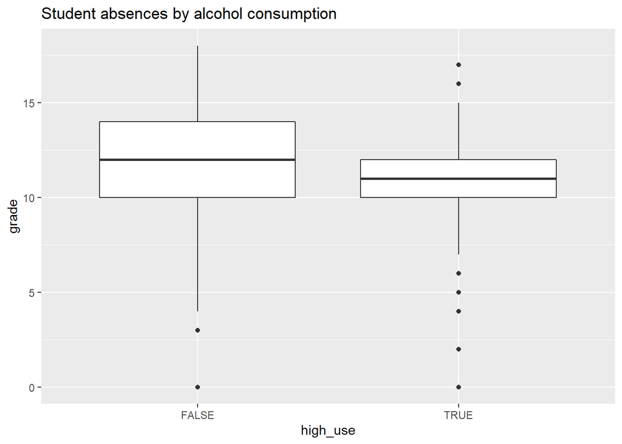

```r
library(ggplot2)
# initialize a plot of high_use and G3
g1 <- ggplot(alc, aes(x = high_use, y = G3))

# define the plot as a boxplot and draw it
g1 + geom_boxplot() + ylab("grade") + ggtitle("Student absences by alcohol consumption")
```

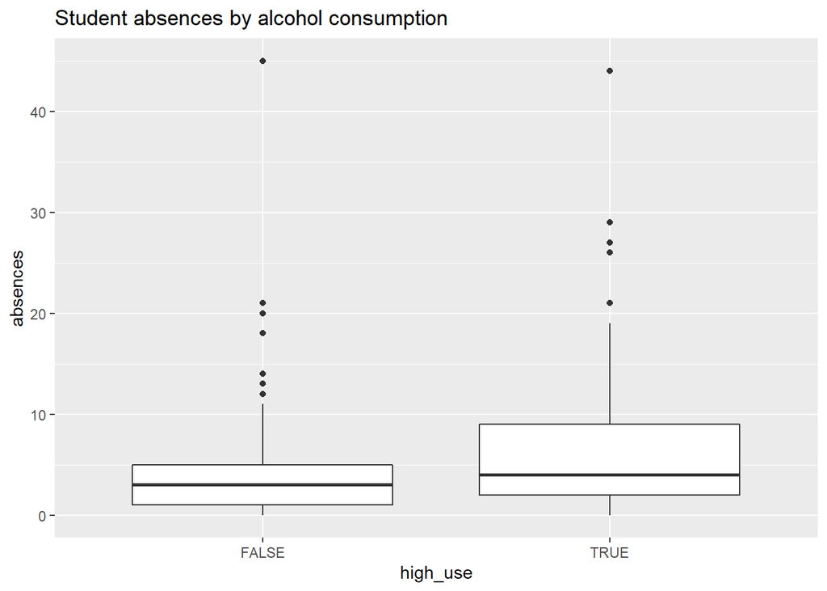

```r
# initialise a plot of high_use and absences
g2 <- ggplot(alc, aes(x = high_use, y = absences))

# define the plot as a boxplot and draw it
g2 + geom_boxplot() + ggtitle("Student absences by alcohol consumption")
```

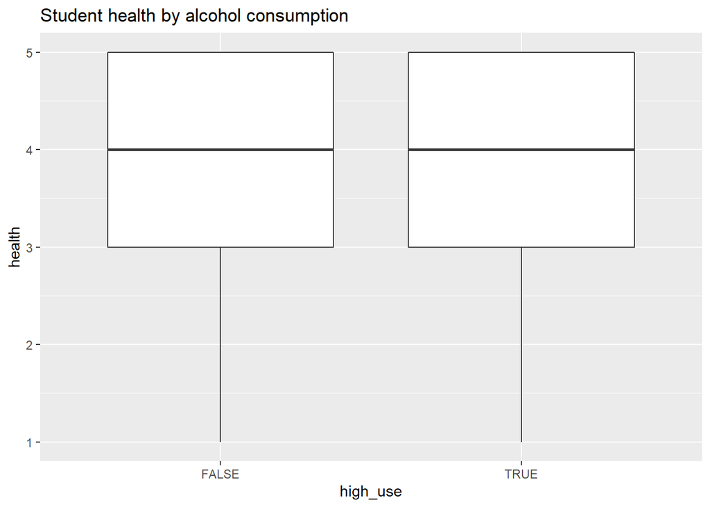

```r
# initialise a plot of high_use and health
g3 <- ggplot(alc, aes(x = high_use, y = health))

# define the plot as a boxplot and draw it
g3 + geom_boxplot() + ggtitle("Student health by alcohol consumption")
```

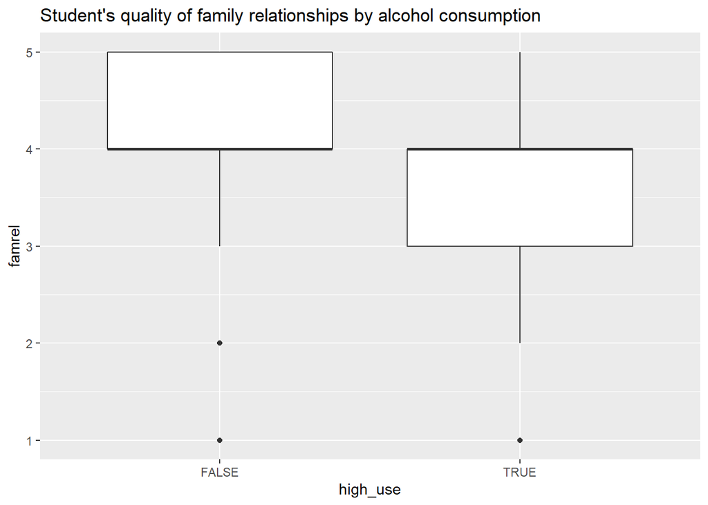

```r
# initialise a plot of high_use and quality of family relationships
g3 <- ggplot(alc, aes(x = high_use, y = famrel))

# define the plot as a boxplot and draw it
g3 + geom_boxplot() + ggtitle("Student's quality of family relationships by alcohol consumption")
```

From the boxplots it seems that the alcohol consumption could be in a relationship with the final grade (G3), where the lower alcohol consumption could lead to better grade. Also, the high alcohol consumption could lead to more absences and students with lower alcohol consumption also seem to have a better quality of family relationships. There seems to be no relationship between the student’s health and the alcohol consumption.

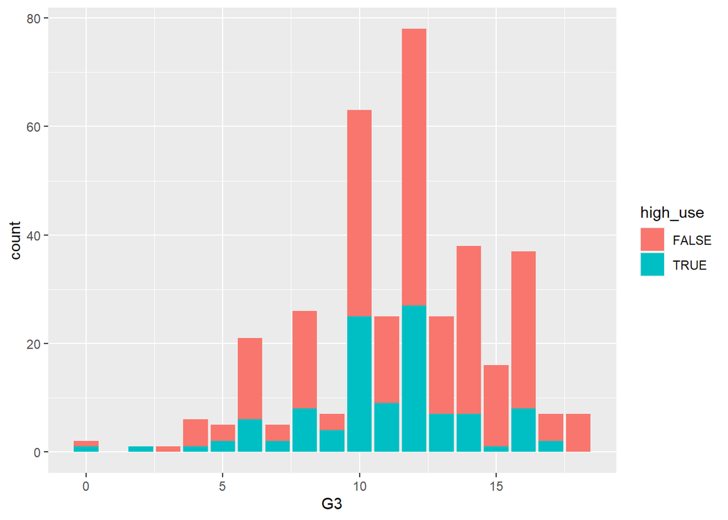

```r
#box plot for the grade by alcohol use
g1 <- ggplot(data = alc, aes(x = G3,fill = high_use))


g1 + geom_bar()
```

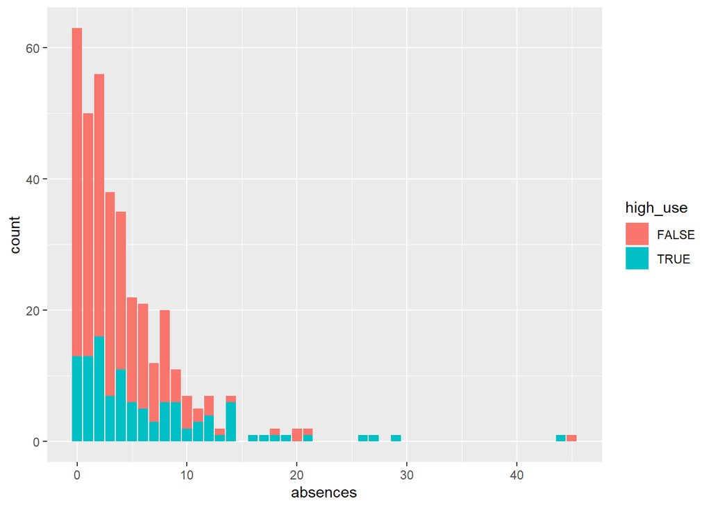

```r
g2 <- ggplot(data = alc, aes(x = absences,fill = high_use))

# define the plot as a bar plot and draw it
g2 + geom_bar()
```

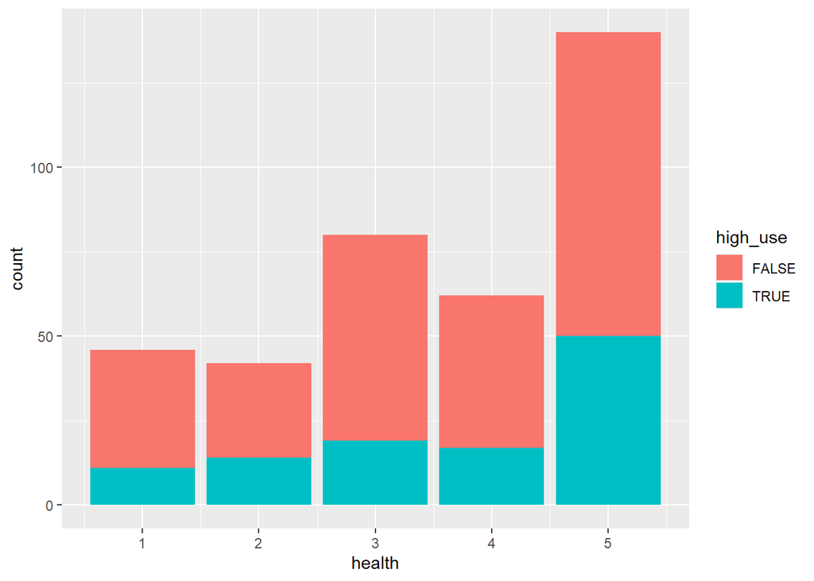

```r
g3 <- ggplot(data = alc, aes(x = health,fill = high_use))

# define the plot as a bar plot and draw it
g3 + geom_bar()
```

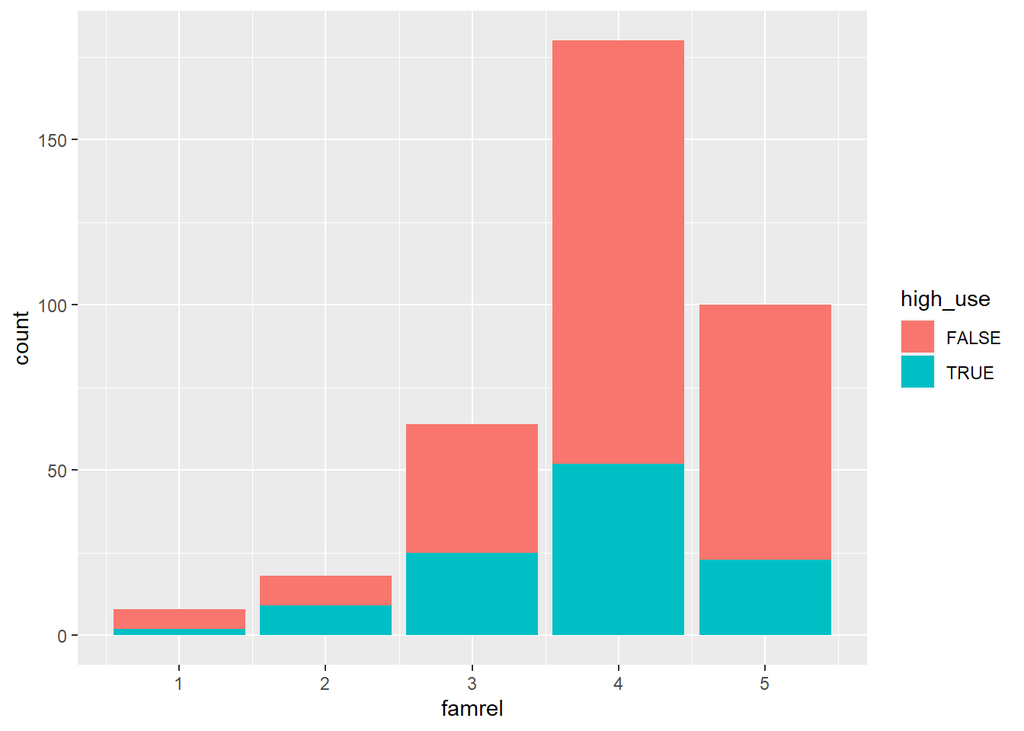

```r
g4 <- ggplot(data = alc, aes(x = famrel,fill = high_use))

# define the plot as a bar plot and draw it
g4 + geom_bar()
```

The logistic model, where the high_use is the target variable and final grade G3, absences, health and quality of family relationships (famrel) are the predictors.

```r
# find the model with glm()
m <- glm(high_use ~ G3 + absences+health+famrel, data = alc, family = "binomial")

# print out a summary of the model
summary(m)
```

```
##
## Call:
## glm(formula = high_use ~ G3 + absences + health + famrel, family = "binomial",
##     data = alc)
##
## Deviance Residuals:
##     Min       1Q   Median       3Q      Max
## -2.3498  -0.8206  -0.6820   1.1424   1.9666
##
## Coefficients:
##             Estimate Std. Error z value Pr(>|z|)
## (Intercept)  0.12490    0.72091   0.173 0.862450
## G3          -0.06840    0.03615  -1.892 0.058439 .
## absences     0.08193    0.02269   3.612 0.000304 ***
## health       0.13687    0.08806   1.554 0.120138
## famrel      -0.27919    0.12753  -2.189 0.028582 *
## ---
## Signif. codes:  0 '***' 0.001 '**' 0.01 '*' 0.05 '.' 0.1 ' ' 1
##
## (Dispersion parameter for binomial family taken to be 1)
##
##     Null deviance: 452.04  on 369  degrees of freedom
## Residual deviance: 423.36  on 365  degrees of freedom
## AIC: 433.36
##
## Number of Fisher Scoring iterations: 4
```

```r
# print out the coefficients of the model
coef(m)
```

```
## (Intercept)          G3    absences      health      famrel
##  0.12490199 -0.06840295  0.08193324  0.13686832 -0.27918935
```

```r
# compute odds ratios (OR)
OR <- coef(m) %>% exp

# compute confidence intervals (CI)
CI <- confint(m) %>% exp
# print out the odds ratios with their confidence intervals
cbind(OR, CI)
```

```
##                    OR     2.5 %    97.5 %
## (Intercept) 1.1330374 0.2735992 4.6635214
## G3          0.9338841 0.8695698 1.0024141
## absences    1.0853833 1.0402838 1.1373505
## health      1.1466771 0.9669919 1.3668428
## famrel      0.7563967 0.5879500 0.9711348
```

```r
# define a loss function (average prediction error)
loss_func <- function(class, prob) {
  n_wrong <- abs(class - prob) > 0.5
  mean(n_wrong)
}

# compute the average number of wrong predictions in the (training) data


# K-fold cross-validation
library(boot)
cv <- cv.glm(data = alc, cost = loss_func, glmfit = m, K = nrow(alc))
cv$delta[1]
```

```
## [1] 0.2918919
```

```r
# average number of wrong predictions in the 10-fold cross validation

cv <- cv.glm(data = alc, cost = loss_func, glmfit = m, K = 10)
# average number of wrong predictions in the 10-fold cross validation
cv$delta[1]
```

```
## [1] 0.2918919
```